# US Airports On-Time Performance 2019 Q1

## by Sophie Wang

## Investigation Overview

This presentation is created to describe the on-time performance of US airports in the first quarter of 2019. It first gives an overview of delayed flights as a proportion of the total. It then dives deeper into flights by delay causes and top 5 most/least punctual airports measured by on-time departure rate in each size category. It ends with the ranking of on-time rate by carriers.

## Dataset Overview

There are two datasets investigated. The first one is the marketing airline on-time performance data provided by Bureau of Transport Statistics. The dataset includes all US domestic flights in the first quarter of 2019 with scheduled departure/arrival time slots and actual ones. The second one comes from Wikipedia page on US airport category. This dataset provides information about FAA category of each individual airport in the US.

## On-time vs. Delayed Flights Overview

> In the first quarter of 2019, approximately 1,911 thousands US domestic flights were operated, out of which 1,513 thousands departed on time or 79.2%. On the other hand, 398 thousands flights were delayed (delay time equal to or greater than 15 minutes), representing 20.8% of the total.

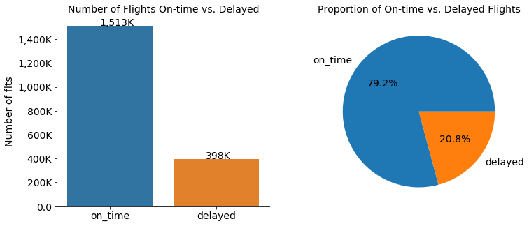

## Number of Delayed Flights by Cause

> Late aircraft arrival is the major reason for flight delays, followed by carrier-related issues such as maintenance, operations. The third biggest driver for late flights concern National Air System issues such as air traffic congestion. Interestingly, delays caused by weather or security line-up at airports are very few compared with the first three causes. In terms of distribution, most of the flights delayed for less than 60 minutes. It's very rare for any flight to be delayed for more than 2 hours.

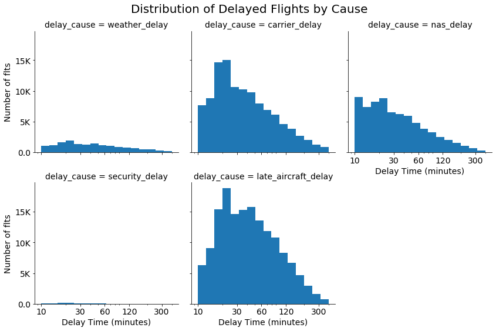

## Average Delay Time by Cause

> On average, delay time due to late aircraft arrival amounts to 35 minutes, compared with 27 minutes caused by carrier-related issues, 14 minutes due to problems concerning national air system. Delay time by security is negligible.

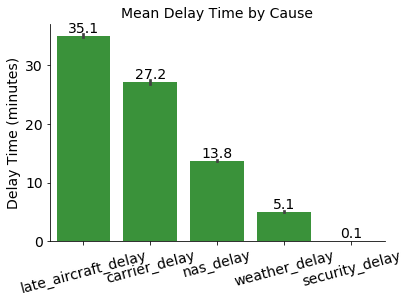

## Top 5 Most Punctual US Airports by Size Category

(measured by number of on-time departures over total flights)

> Honolulu(IATA airport code:HNL) ranks first in terms of on-time departure among all large airports in the US thanks in part to its favorable weather all-year round. Portland comes in second, followed by Atlanta (ATL), Philadelphia(PHL) and Salt Lake City(SLC). In the medium size category, Anchorage(ANC) tops the chart. It's followed by Kahului(OGG), the airport serving Maui. San Antonio, El Paso, both in Texas, along with Jacksonville in Florida, rank from third to fifth. Hilo(ITO), another Hawaiian airport, is crowned in the small size category for its stellar on-time performance. It achieved a 92.2% on-time departure rate in the first quarter of 2019. The other winners in this category are: Atlantic City(ACY), Fairbanks(FAI), Clearwater(PIE) and Guam(GUM).

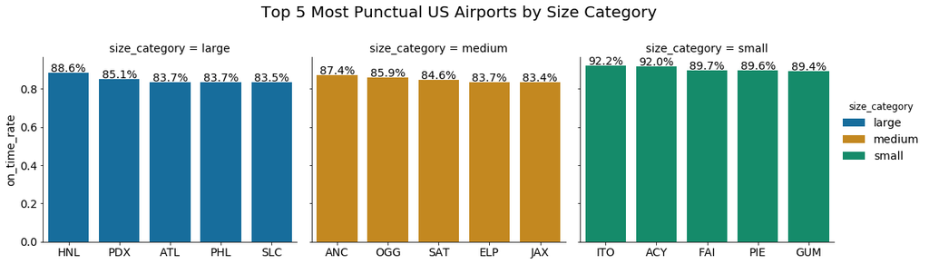

## Top 5 Least Punctual US Airports by Size Category

> It's interesting to see that 4 out of the five least Punctual performers in the large airport category concentrate in New York (Laguardia LGA and Newark EWR) and Chicago (O'Hare ORD and Midway MDW). And the remaining one serves San Francisco (SFO). The worst of the top 5 Chicago Midway, saw only 63.5% of its flights depart on-time in the first quarter of 2019 Among the medium-sized airports, Oakland, another airport in the Bay Area, makes to the list. West Palm Beach(PBI), St. Louis(STL), Dallas Love Field and Houston make up for the rest. The worst of all is Houston, which scored a 74.4% on-time departure rate. The top 5 least punctual small US airports concentrate in the Midwest: Grand Rapids(GRR) in Michigan, Sioux Falls(FSD) in North Dakota, Eastern Iowa(CID), Fargo(FAR) in North Dakota. There is only one exception Burlington(BTV) in Vermont.

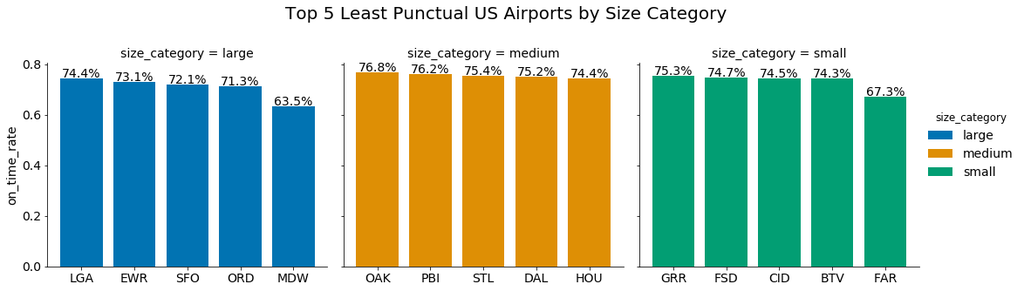

## US Airlines On-time Performance Ranking

Hawaiian Airlines(HA) outperformed its competitors in regards to on-time departures. It achieved an average on-time rate of 89% for its flights in the first quarter of 2019. Spirit(NK), its immediate follower in the ranking only reached 84%, a full 5 percentage points behind. Delta Air Lines(DL) is the third. The least punctual carrier title, unfortunately, goes to JetBlue(B6), possibly driven by disastrous weather in January along the East Coast, where its hubs locate.

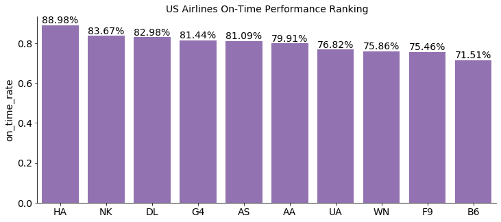